# Forecasting daily electricity load using `fable` and `modeltime`

IDI-II. PhD in Engineering Sciences

Pablo Benavides-Herrera

2020-08-20

# 1 Introduction

## 1.1 Packages

The packages necessary to run this notebook are the following.

```r
library(tidyverse) # data cleaning, wrangling, plotting
library(lubridate) # dates handling
library(patchwork) # plot setup
library(plotly)    # interactive plots

# the tidyverts
library(tsibble)
library(feasts)
library(fable)
library(fable.prophet)
library(fasster)

# modeltime
library(tidymodels)
library(modeltime)
```

## 1.2 The data

The main data to be used is the daily load from the Western Regional Control Management of CENACE. We also use holidays data as to get insights on the variation.

```r
datos <- read_csv("gcroc.csv")
festivos <- read_csv("festivos_utf8.csv")
datos <- datos %>%
  left_join(festivos, by = c("fecha" = "fecha"))

datos <- datos %>%
  mutate(fecha = dmy(fecha),
         dia_semana = factor(dia_semana,
                             levels = c(1:7)),
         Day_type = case_when(
           festivo %in% festivos$festivo ~ "Holiday",
           wday(fecha,week_start = 1) == 1 ~ "Monday",
           wday(fecha, week_start = 1) %in% 1:5 ~ "Weekday",
           TRUE ~ "Weekend"
         ) %>% factor(levels = c("Monday","Weekday",
                                 "Weekend","Holiday")),
         Month = month(fecha, label = TRUE) %>% factor(ordered = F)
         ) %>%
  as_tsibble(index = fecha) %>%
  rename(`temp min` = temp_min,
         `temp max` = temp_max,
         `temp prom` = temp_prom)
datos
```

| fecha | MWh | temp min | temp max | temp prom | nubosidad | lluvia | viento | dia_semana | festivo | Day_type | Month |
| --- | --- | --- | --- | --- | --- | --- | --- | --- | --- | --- | --- |
| 2001-12-29 | 100564.52 | 9.642857 | 22.85714 | 16.25000 | NA | NA | 23.61111 | 6 | NA | Weekend | dic |
| 2001-12-30 | 91005.54 | 9.357143 | 22.85714 | 16.10714 | NA | NA | 23.61111 | 7 | NA | Weekend | dic |
| 2001-12-31 | 92677.95 | 9.428571 | 23.00000 | 16.21429 | NA | NA | 23.61111 | 1 | NA | Monday | dic |
| 2002-01-01 | 80498.49 | 10.142857 | 23.35714 | 16.75000 | NA | NA | 23.61111 | 2 | año nuevo | Holiday | ene |
| 2002-01-02 | 100411.91 | 9.714286 | 23.07143 | 16.39286 | NA | NA | 23.61111 | 3 | NA | Weekday | ene |
| 2002-01-03 | 108023.06 | 9.571429 | 23.50000 | 16.53571 | NA | NA | 23.61111 | 4 | NA | Weekday | ene |
| 2002-01-04 | 109878.13 | 9.357143 | 23.50000 | 16.42857 | NA | NA | 23.61111 | 5 | NA | Weekday | ene |
| 2002-01-05 | 105317.89 | 9.785714 | 23.28571 | 16.53571 | NA | NA | 23.61111 | 6 | NA | Weekend | ene |
| 2002-01-06 | 92808.64 | 9.500000 | 22.64286 | 16.07143 | NA | NA | 23.61111 | 7 | NA | Weekend | ene |
| 2002-01-07 | 106221.17 | 9.500000 | 22.78571 | 16.14286 | NA | NA | 23.61111 | 1 | NA | Monday | ene |

[output cut: 990 more lines]

# 2 Exploratory Data Analysis (EDA)

## 2.1 Visual inspection

We begin by plotting the data in a time plot, as well as in boxplots, first by day type, and then by month, as to check if we can find differences across time.

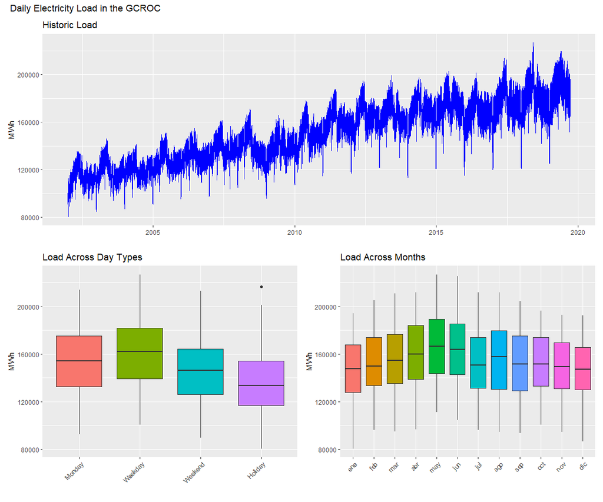

```r
g1 <- ggplot(datos,aes(x = fecha, y = MWh)) + xlab("")
# Time plot
p1 <- g1 + geom_line(color = "blue") +
  ggtitle("Historic Load")
# Day type boxplot
p2 <- g1 + geom_boxplot(aes(x = Day_type, fill = Day_type)) +
  theme(legend.position = "none",
        axis.text.x =  element_text(angle = 45,
                                      hjust = 1)) +
  ggtitle("Load Across Day Types")
# Month boxplot
p3 <- g1 + geom_boxplot(aes(x = Month,
  fill = Month)
  ) +
  theme(legend.position = "none",
        axis.text.x =  element_text(angle = 45,
                                      hjust = 1)) +
  ggtitle("Load Across Months")
# plot group 1
pg1 <- p1 / (p2 | p3)

pg1 + plot_annotation(
  title = " Daily Electricity Load in the GCROC"
)
```

As can be seen from the time plot, the data exhibits a long-term upward trend, as well as indications of seasonality.

By inspecting both boxplots, we see that differences arise both across day types (whether it is a Monday, weekday, weekend or holidays), and across months, further suggesting two types of seasonality: weekly and yearly.

```r
datos  %>%
  features_if(is_double,features =
                         list(
       Mean = (~ mean(., na.rm = TRUE)),
       `Std. Dev.` = (~ sd(., na.rm = TRUE)),
       Min = (~ min(., na.rm = TRUE)),
       Median = (~ median(., na.rm = TRUE)),
       Max = (~ max(., na.rm = TRUE)),
       N = length)
       ) %>%
  pivot_longer(everything()) %>%
  separate(name, into = c("var","stat"), sep = "_") %>%
  pivot_wider(names_from = "var",values_from = "value")
```

| stat | MWh | temp min | temp max | temp prom | nubosidad | lluvia | viento |
| --- | --- | --- | --- | --- | --- | --- | --- |
| Mean | 154904.25 | 14.564601 | 27.945136 | 21.254869 | 32.93494 | 3.7887735 | 26.262436 |
| Std. Dev. | 26330.35 | 3.076820 | 2.570682 | 2.510594 | 18.22625 | 8.2263127 | 3.903947 |
| Min | 80498.49 | 2.355646 | 16.642857 | 10.694059 | 7.19732 | -0.1928381 | 14.793750 |
| Median | 153642.14 | 15.285714 | 28.071429 | 21.826918 | 25.59458 | 0.0000000 | 26.750000 |
| Max | 226772.62 | 22.000000 | 35.190460 | 27.214286 | 99.33452 | 62.2916744 | 81.000000 |
| N | 6477.00 | 6477.000000 | 6477.000000 | 6477.000000 | 6477.00000 | 6477.0000000 | 6477.000000 |

We check for the relationship between electricity load and temperature across day types.

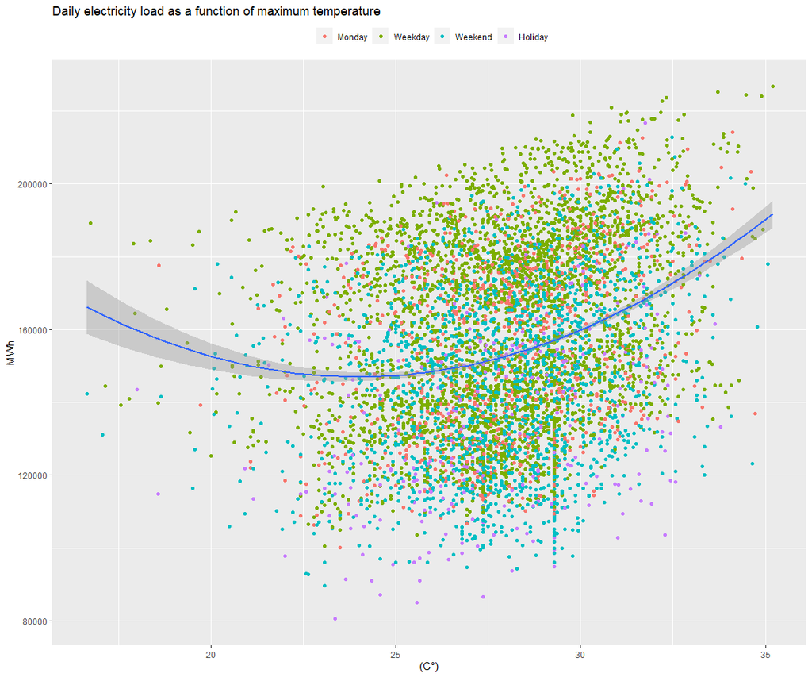

```r
p4 <- datos %>%
  filter(year(fecha)>2001) %>%
  ggplot(aes(x = `temp max`, y = MWh)) +
  geom_point(aes(color = Day_type)) +
  ggtitle("Daily electricity load as a function of maximum temperature") +
  xlab("(C°)") +
  geom_smooth(method = "lm", formula = y ~ x + I(x^2)) +
  labs(color = "") +
  theme(legend.position = "top")


p4
```

The data show a u-shape trend. Whenever the maximum temperature is low, the energy demand seems to be higher. The same happens and even in a greater degree when the maximum temperature is high.

From the image above we can see that holidays and weekends seem to be on the lower part of the plot, while mondays and weekdays tend to cluster higher. The separation between them is not as clear, and it could be because of the upward trend over the years.

We could plot each year separately to get a better look at it, or remove the trend from the series.

Plotting each year separately yields the plot below.

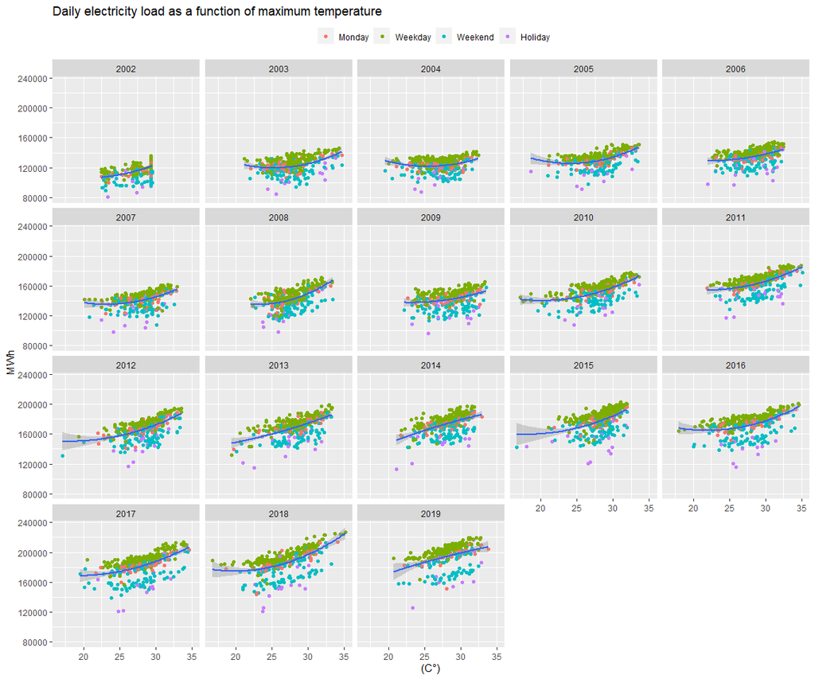

```r
p4 + facet_wrap(~ factor(year(fecha)))
```

Removing the trend using an STL decomposition:

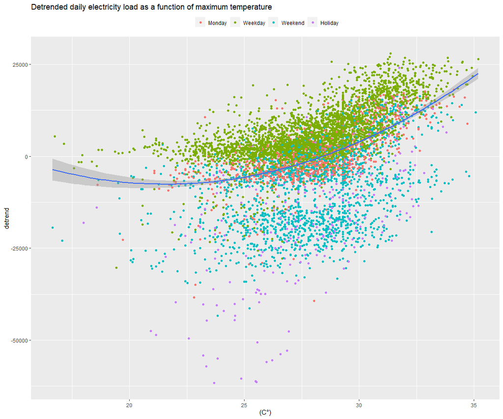

```r
p5 <- datos %>%
  mutate(detrend = MWh - datos %>%
           model(STL(MWh)) %>%
           components() %>%
           pull(trend)
           ) %>%
  ggplot(aes(x = `temp max`, y = detrend)) +
  geom_point(aes(color = Day_type)) +
  ggtitle("Detrended daily electricity load as a function of maximum temperature") +
  xlab("(C°)") +
  labs(color = "") +
  theme(legend.position = "top")

p5 +
  geom_smooth(method = "lm", formula = y ~ x + I(x^2))
```

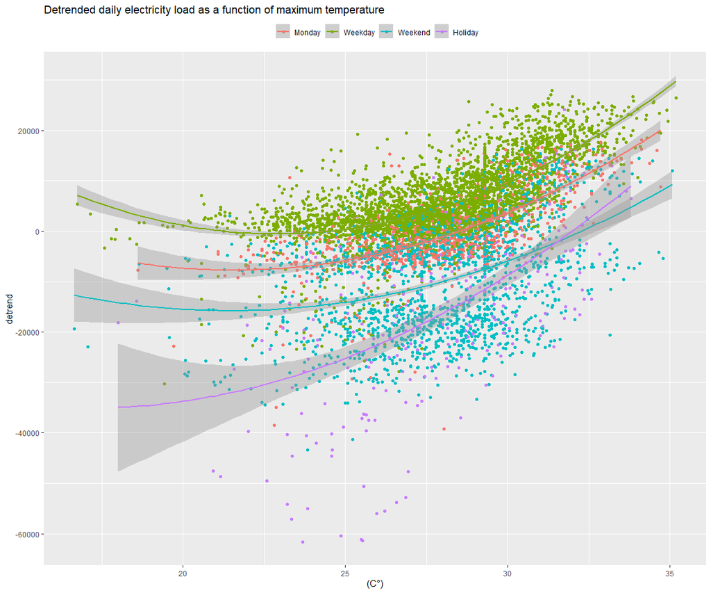

```r
p5 +
  geom_smooth(method = "lm", formula = y ~ x + I(x^2),
              aes(color = Day_type))
```

In both cases, we can now see clearer clusters forming, supporting what we saw on the boxplots. Also, adding a global trend line or a trend line for each day type shows a similar pattern.

## 2.2 Data transformations

We check to see whether performing a transformation to our data could help us reduce irrelevant variation.

First, we take the log values.

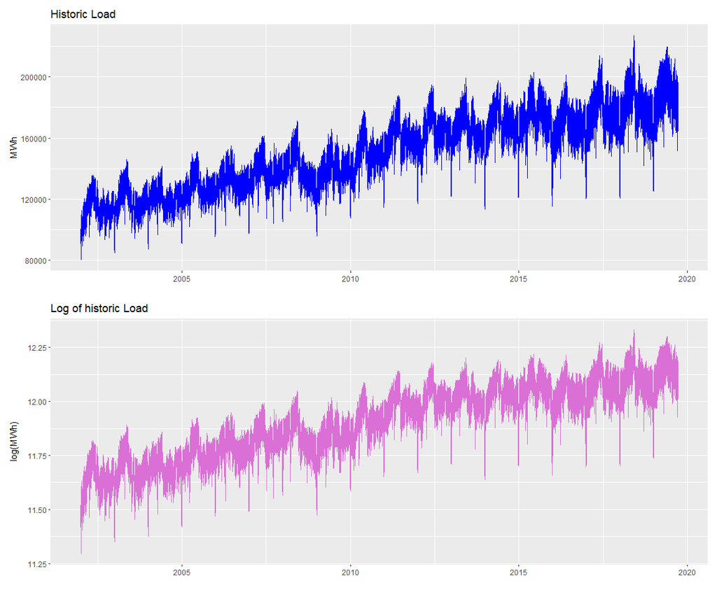

```r
p1_log <- g1 + geom_line(aes(y = log(MWh)), color = "orchid") +
  ggtitle("Log of historic Load") + ylab("log(MWh)")

p1 / p1_log
```

Now, we try using a Box-Cox transformation, choosing lambda with the Guerrero feature.

```r
lambda <- datos %>%
  features(MWh, features = guerrero) %>%
  pull(lambda_guerrero)

lambda
```

```
[1] 0.09230253
```

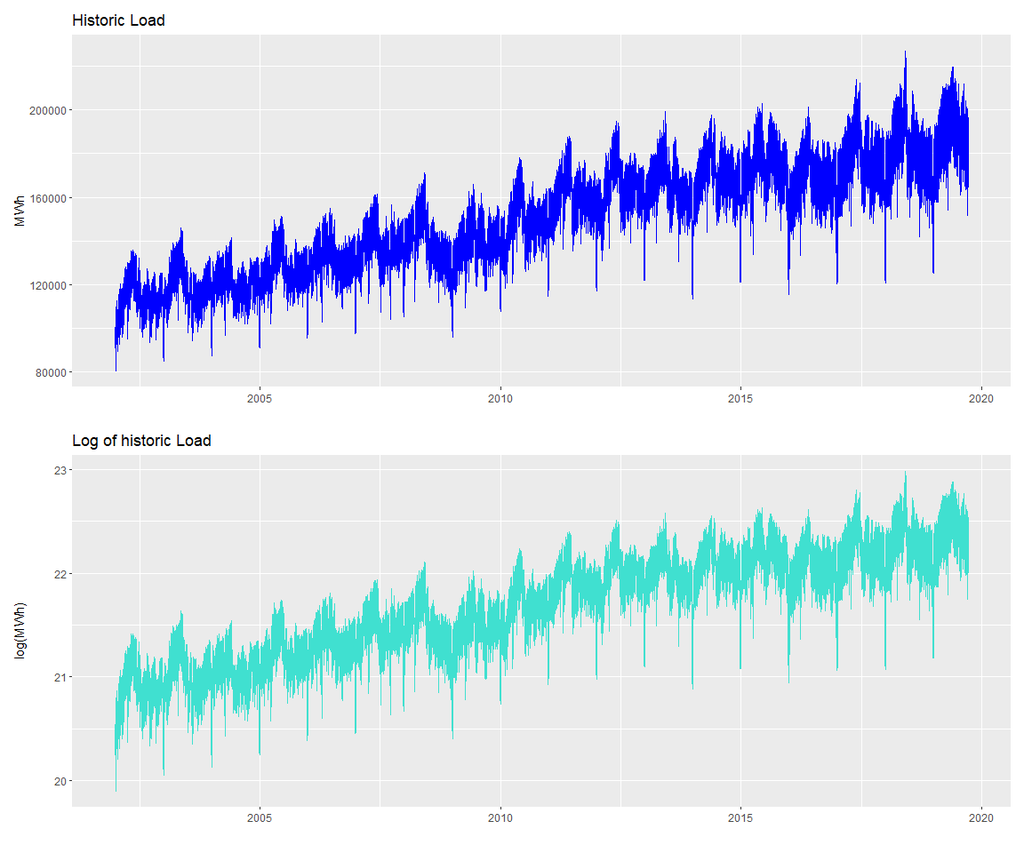

```r
p1_boxcox <- g1 + geom_line(aes(y = box_cox(MWh, lambda = lambda)), color = "turquoise") +
  ggtitle("Log of historic Load") + ylab("log(MWh)")

p1 / p1_boxcox
```

# 3 `R` Packages for modeling and forecasting

We will produce forecasts using a wide variety of models, with two different `R` packages: `fable` and `modeltime`.

## 3.1 `fable` and the tidyver**ts** ecosystem

A generalized function to obtain forecasts via `fable` is shown below. One must specify the model with as much customization as needed.

```r
fable_workflow <- function(data = datos, model, lag = 10, dof = 0, horizon = 30, year = 2018){
  # Splitting data into train and test sets
  train <- data %>%
    slice_head(n = (nrow(data) - horizon))

  test <- datos %>%
    slice_tail(n = horizon)

  # fitting the model
  fable <- train %>%
    model(model)

  print("The fitted model:")
  fable %>%
    report()

  print("Training accuracy:")
  fable %>%
    fabletools::accuracy() %>%
    print()

  # Residual diagnostics:
  resids <- fable %>%
    gg_tsresiduals() +
    ggtitle("Residual diagnostics")
  print(resids)

  print("Portmanteau tests for autocorrelation")
  fable %>%
    augment() %>%
    features(.resid, ljung_box, lag = lag, dof = dof) %>%
    print()


  print("The forecast:")
  fable_fcst <- fable %>%
    forecast(h = horizon)
  print(fable_fcst)

  # Plotting the forecast:
  fcst <-
    # Historic data vs. forecast
    fable_fcst %>%
    autoplot(data) /
    # recent history vs. forecast
    fable_fcst %>%
    autoplot(data %>% filter(year(fecha)>year)) +
    plot_annotation(title = "The Forecast")
  print(fcst)

  print("Forecast accuracy:")
  fable_fcst %>%
    fabletools::accuracy(test) %>%
    print()

}
```

## 3.2 `modeltime`: and extension to the `tidymodels`

# 4 The models

Below we implement many of the models available in both packages.

## 4.1 Time series decomposition

There are many decomposition methods.

### 4.1.2 `fable`

#### 4.1.2.1 Classical decomposition

[figure not shown]

```r
datos %>%
  model(classical_decomposition(MWh, type = "multiplicative")) %>%
  components() %>%
  autoplot() + xlab("year") +
  ggtitle("Classical additive decomposition")
```

#### 4.1.2.2 STL decomposition

An STL decomposition is obtained with the following code.

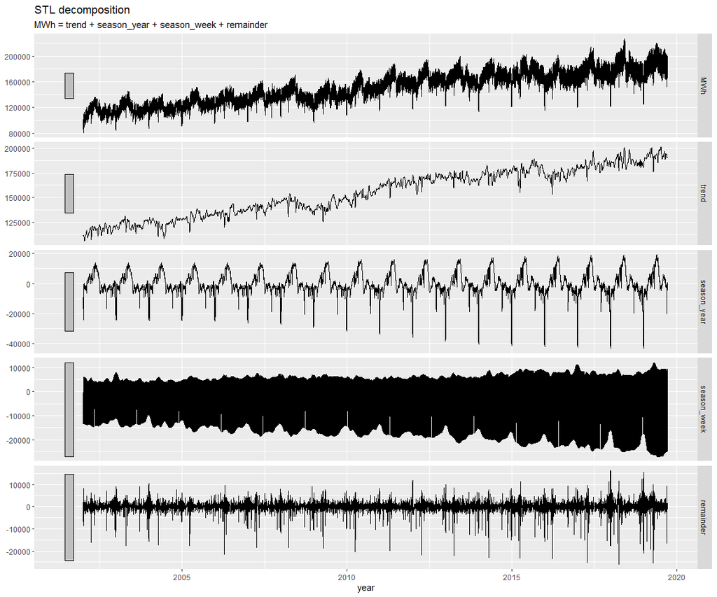

```r
datos %>%
  model(STL(MWh)) %>%
  components() %>%
  autoplot() + xlab("year") +
  ggtitle("STL decomposition")
```

The multiple STL decomposition can be customized. In this case, we want to make the trend smoother.

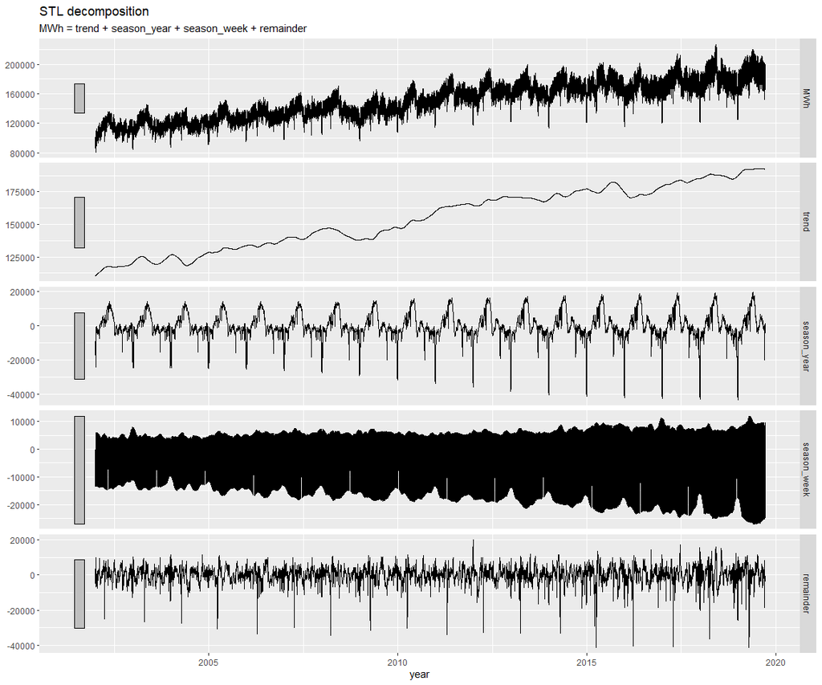

```r
datos %>%
  model(STL(MWh ~ trend(window = 183))) %>%
  components() %>%
  autoplot() + xlab("year") +
  ggtitle("STL decomposition")
```

We could set the seasonality to be fixed specifying `season(window = 'periodic')`.

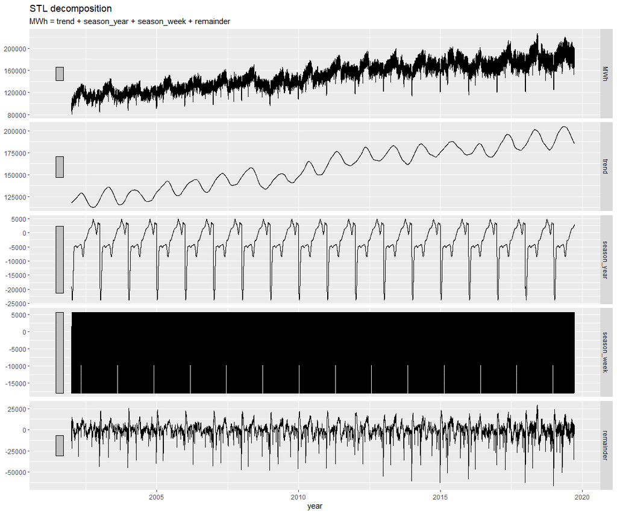

```r
datos %>%
  model(STL(MWh ~ trend(window = 183) +
              season(window = 'periodic'))) %>%
  components() %>%
  autoplot() + xlab("year") +
  ggtitle("STL decomposition")
```

- Modeling and forecasting using STL and ARIMA:

```
Non-integer lag orders for random walk models are not supported. Rounding to the nearest integer.
```

```
[1] "The fitted model:"
Series: MWh
Model: STL decomposition model
Combination: season_adjust + season_year + season_week

======================================================

Series: season_adjust + season_year
Model: COMBINATION
Combination: season_adjust + season_year

========================================

Series: season_adjust
Model: ARIMA(1,1,3) w/ drift

Coefficients:
         ar1      ma1      ma2     ma3  constant
      0.8045  -1.0198  -0.0765  0.1152    2.4885
s.e.  0.0181   0.0228   0.0179  0.0175    0.8128

sigma^2 estimated as 11852975:  log likelihood=-61641.09
AIC=123294.2   AICc=123294.2   BIC=123334.8

Series: season_year
Model: SNAIVE

sigma^2: 288972.6866


Series: season_week
Model: SNAIVE

sigma^2: 133957.794

[1] "Training accuracy:"
```

| .model | .type | ME | RMSE | MAE | MPE | MAPE | MASE | ACF1 |
| --- | --- | --- | --- | --- | --- | --- | --- | --- |
| model | Training | -4.511435 | 3494.481 | 2216.358 | -0.06548714 | 1.477167 | 0.4072338 | 0.02413771 |

```
[1] "Portmanteau tests for autocorrelation"
```

| .model | lb_stat | lb_pvalue |
| --- | --- | --- |
| model | 21.95631 | 0.01532875 |

```
[1] "The forecast:"
```

| .model | fecha | MWh | .mean |
| --- | --- | --- | --- |
| model | 2019-08-24 |  | 192493.5 |
| model | 2019-08-25 |  | 169637.6 |
| model | 2019-08-26 |  | 196532.7 |
| model | 2019-08-27 |  | 204400.0 |
| model | 2019-08-28 |  | 206722.3 |
| model | 2019-08-29 |  | 205044.6 |
| model | 2019-08-30 |  | 201002.3 |
| model | 2019-08-31 |  | 190515.8 |
| model | 2019-09-01 |  | 166971.7 |
| model | 2019-09-02 |  | 192608.7 |

[output cut: 20 more lines]

```
[1] "Forecast accuracy:"
```

| .model | .type | ME | RMSE | MAE | MPE | MAPE | MASE | ACF1 |
| --- | --- | --- | --- | --- | --- | --- | --- | --- |
| model | Test | -3000.536 | 6714.264 | 4597.606 | -1.689086 | 2.572904 | NaN | 0.1427454 |

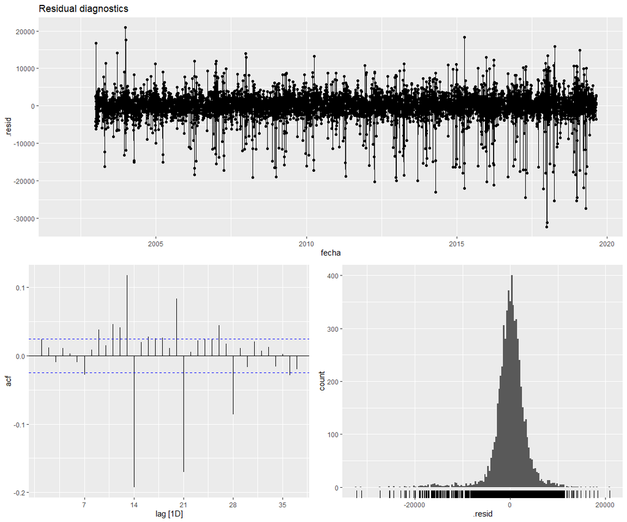

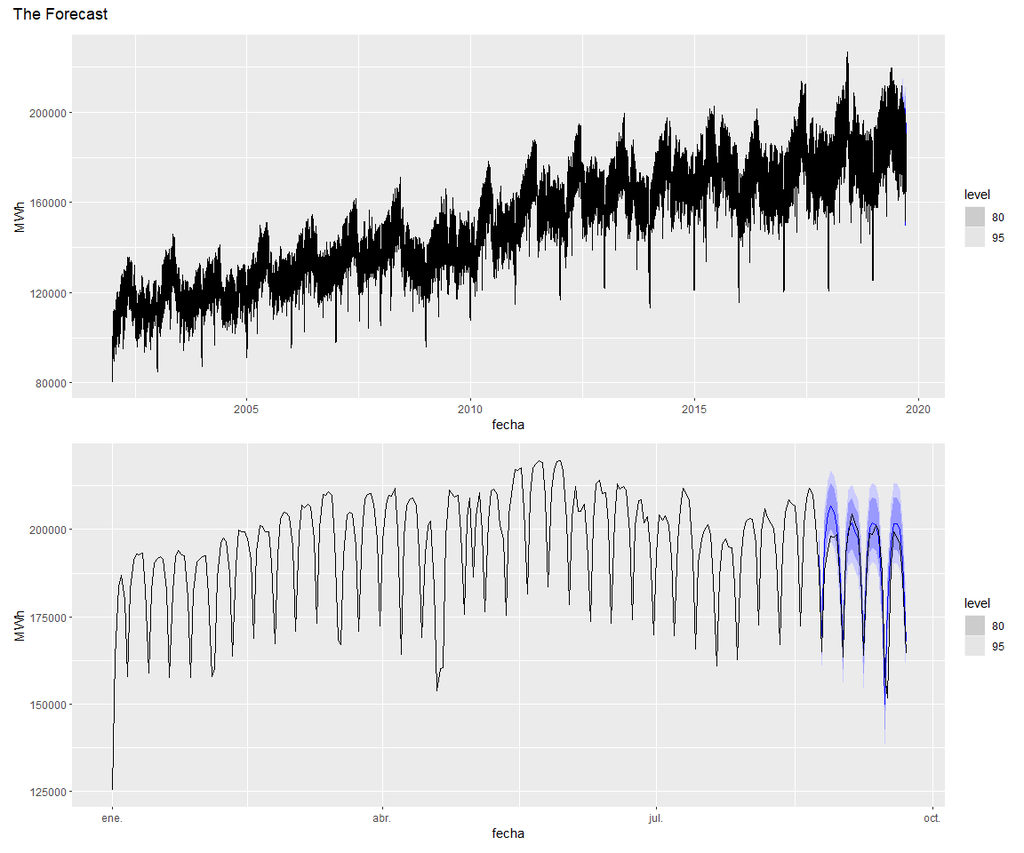

```r
fable_workflow(data = datos,
               model = decomposition_model(
                 STL(MWh ~ trend(window = 183)),
                 ARIMA(season_adjust ~ PDQ(0,0,0))
               ))
```

- Using STL and ETS:

```
Non-integer lag orders for random walk models are not supported. Rounding to the nearest integer.
```

```
[1] "The fitted model:"
Series: MWh
Model: STL decomposition model
Combination: season_adjust + season_year + season_week

======================================================

Series: season_adjust + season_year
Model: COMBINATION
Combination: season_adjust + season_year

========================================

Series: season_adjust
Model: ETS(A,N,N)
  Smoothing parameters:
    alpha = 0.818386

  Initial states:
        l
 111783.5

  sigma^2:  13127560

     AIC     AICc      BIC
162220.8 162220.8 162241.1

Series: season_year
Model: SNAIVE

sigma^2: 288972.6866


Series: season_week
Model: SNAIVE

sigma^2: 133957.794

[1] "Training accuracy:"
```

| .model | .type | ME | RMSE | MAE | MPE | MAPE | MASE | ACF1 |
| --- | --- | --- | --- | --- | --- | --- | --- | --- |
| model | Training | 14.60555 | 3677.191 | 2291.516 | -0.0387776 | 1.530208 | 0.4210433 | 0.05792458 |

```
[1] "Portmanteau tests for autocorrelation"
```

| .model | lb_stat | lb_pvalue |
| --- | --- | --- |
| model | 314.354 | 0 |

```
[1] "The forecast:"
```

| .model | fecha | MWh | .mean |
| --- | --- | --- | --- |
| model | 2019-08-24 |  | 193247.4 |
| model | 2019-08-25 |  | 169977.3 |
| model | 2019-08-26 |  | 196939.3 |
| model | 2019-08-27 |  | 204858.0 |
| model | 2019-08-28 |  | 207219.1 |
| model | 2019-08-29 |  | 205570.1 |
| model | 2019-08-30 |  | 201548.5 |
| model | 2019-08-31 |  | 191076.2 |
| model | 2019-09-01 |  | 167540.9 |
| model | 2019-09-02 |  | 193182.5 |

[output cut: 20 more lines]

```
[1] "Forecast accuracy:"
```

| .model | .type | ME | RMSE | MAE | MPE | MAPE | MASE | ACF1 |
| --- | --- | --- | --- | --- | --- | --- | --- | --- |
| model | Test | -3506.331 | 6939.34 | 4853.82 | -1.958438 | 2.712135 | NaN | 0.1368934 |

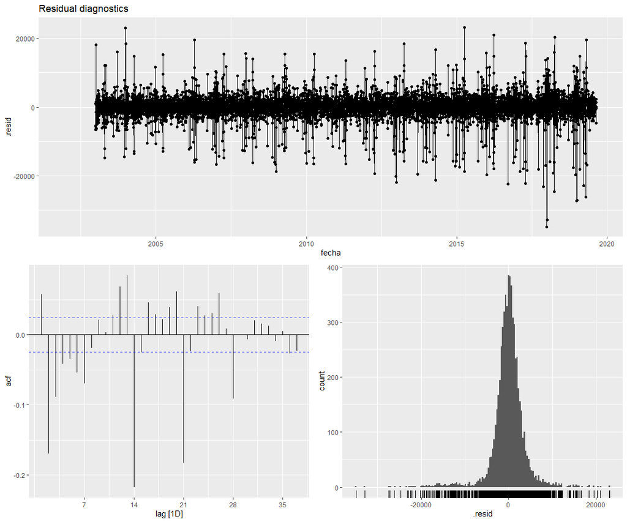

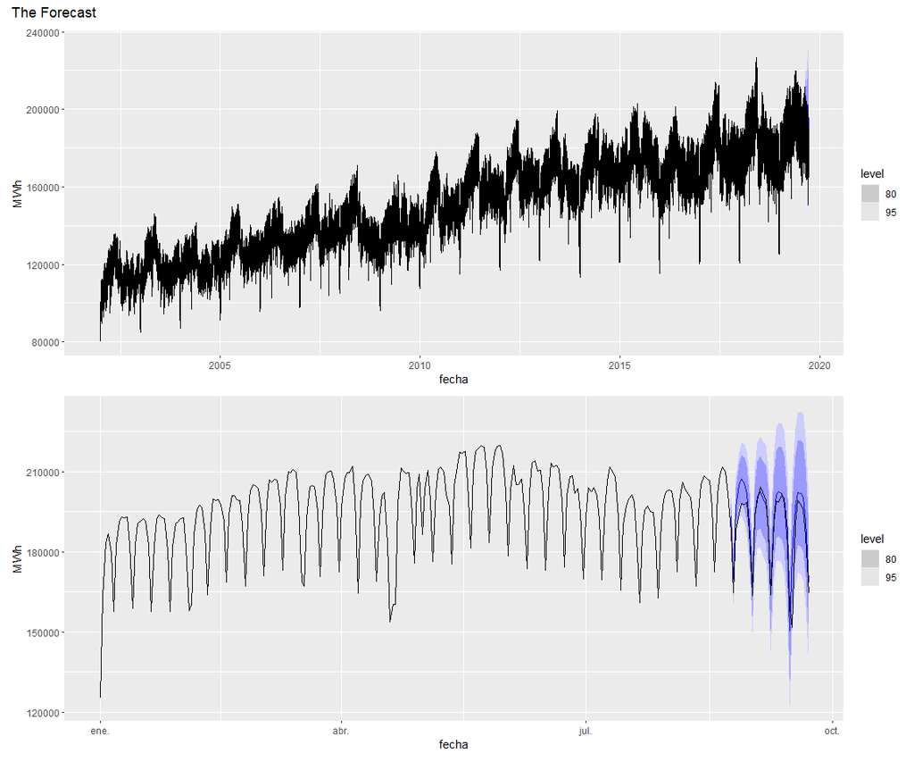

```r
fable_workflow(data = datos,
               model = decomposition_model(
                 STL(MWh ~ trend(window = 183)),
                 ETS(season_adjust ~ season("N"))
               ))
```

- Using STL, ARIMA, fourier:

```
[1] "The fitted model:"
Series: MWh
Model: STL decomposition model
Combination: season_adjust + season_year + season_week

======================================================

Series: season_adjust + season_year
Model: COMBINATION
Combination: season_adjust + season_year

========================================

Series: season_adjust
Model: ARIMA(1,1,3) w/ drift

Coefficients:
         ar1      ma1      ma2     ma3  constant
      0.8045  -1.0198  -0.0765  0.1152    2.4885
s.e.  0.0181   0.0228   0.0179  0.0175    0.8128

sigma^2 estimated as 11852975:  log likelihood=-61641.09
AIC=123294.2   AICc=123294.2   BIC=123334.8

Series: season_year
Model: TSLM

Residuals:
     Min       1Q   Median       3Q      Max
-28461.4  -1517.7    151.3   1828.0  10326.2

Coefficients:
                                          Estimate Std. Error t value
(Intercept)                                  10.90      43.14   0.253
fourier(K = 10, period = "1 year")C1_365  -5566.98      60.85 -91.487
fourier(K = 10, period = "1 year")S1_365   4673.11      61.16  76.410
fourier(K = 10, period = "1 year")C2_365  -2071.86      61.02 -33.956
fourier(K = 10, period = "1 year")S2_365  -2824.37      60.99 -46.306
fourier(K = 10, period = "1 year")C3_365    159.14      61.02   2.608
fourier(K = 10, period = "1 year")S3_365   1423.81      60.98  23.348
```

[output cut: 57 more lines]

```
fourier(K = 2, period = "1 week")S2_7  4206.5756    55.1461  76.281
                                      Pr(>|t|)
(Intercept)                               0.98
fourier(K = 2, period = "1 week")C1_7   <2e-16 ***
fourier(K = 2, period = "1 week")S1_7   <2e-16 ***
fourier(K = 2, period = "1 week")C2_7   <2e-16 ***
fourier(K = 2, period = "1 week")S2_7   <2e-16 ***
---
Signif. codes:  0 ‘***’ 0.001 ‘**’ 0.01 ‘*’ 0.05 ‘.’ 0.1 ‘ ’ 1

Residual standard error: 3131 on 6442 degrees of freedom
Multiple R-squared: 0.8493, Adjusted R-squared: 0.8492
F-statistic:  9076 on 4 and 6442 DF, p-value: < 2.22e-16

[1] "Training accuracy:"
```

| .model | .type | ME | RMSE | MAE | MPE | MAPE | MASE | ACF1 |
| --- | --- | --- | --- | --- | --- | --- | --- | --- |
| model | Training | 2.060309 | 5995.116 | 4139.287 | -0.1536424 | 2.806581 | 0.760553 | 0.1685569 |

```
[1] "Portmanteau tests for autocorrelation"
```

| .model | lb_stat | lb_pvalue |
| --- | --- | --- |
| model | 1442.971 | 0 |

```
[1] "The forecast:"
```

| .model | fecha | MWh | .mean |
| --- | --- | --- | --- |
| model | 2019-08-24 |  | 191446.4 |
| model | 2019-08-25 |  | 181776.8 |
| model | 2019-08-26 |  | 191447.6 |
| model | 2019-08-27 |  | 202279.4 |
| model | 2019-08-28 |  | 199829.1 |
| model | 2019-08-29 |  | 199438.0 |
| model | 2019-08-30 |  | 200939.6 |
| model | 2019-08-31 |  | 189132.7 |
| model | 2019-09-01 |  | 178819.5 |
| model | 2019-09-02 |  | 188370.2 |

[output cut: 20 more lines]

```
[1] "Forecast accuracy:"
```

| .model | .type | ME | RMSE | MAE | MPE | MAPE | MASE | ACF1 |
| --- | --- | --- | --- | --- | --- | --- | --- | --- |
| model | Test | -2570.713 | 9259.848 | 6336.249 | -1.741168 | 3.644039 | NaN | 0.2813678 |

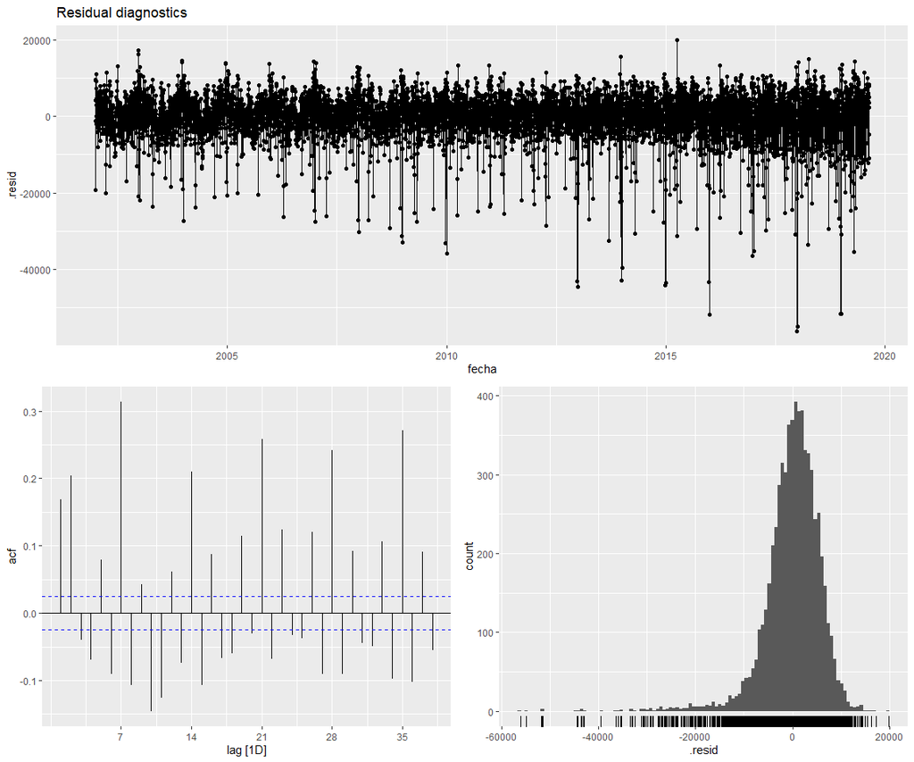

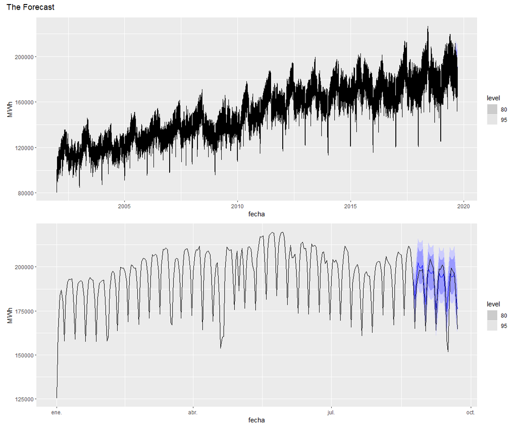

```r
fable_workflow(data = datos,
               model = decomposition_model(
                 STL(MWh ~ trend(window = 183)),
                 ARIMA(season_adjust ~ PDQ(0,0,0)),
                 TSLM(season_year ~ fourier(K = 10, period = "1 year")),
                 TSLM(season_week ~ fourier(K = 2, period = "1 week"))
               ))
```

### 4.1.3 `modeltime`

## 4.2 Exponential smoothing

### 4.2.1 .

### 4.2.2 `fable`

```
[1] "The fitted model:"
Series: MWh
Model: ETS(A,N,A)
  Smoothing parameters:
    alpha = 0.9533124
    gamma = 0.04265283

  Initial states:
      l       s1       s2       s3       s4        s5
 106379 4727.049 5687.695 5698.116 4774.703 -1353.729
        s6        s7
 -16734.81 -2799.022

  sigma^2:  24853134

     AIC     AICc      BIC
166342.7 166342.8 166410.4
[1] "Training accuracy:"
```

| .model | .type | ME | RMSE | MAE | MPE | MAPE | MASE | ACF1 |
| --- | --- | --- | --- | --- | --- | --- | --- | --- |
| model | Training | 14.27647 | 4981.811 | 2950.312 | -0.0561696 | 2.020314 | 0.5420905 | 0.03531688 |

```
[1] "Portmanteau tests for autocorrelation"
```

| .model | lb_stat | lb_pvalue |
| --- | --- | --- |
| model | 754.9447 | 0 |

```
[1] "The forecast:"
```

| .model | fecha | MWh | .mean |
| --- | --- | --- | --- |
| model | 2019-08-24 |  | 192315.4 |
| model | 2019-08-25 |  | 169086.7 |
| model | 2019-08-26 |  | 194375.4 |
| model | 2019-08-27 |  | 201292.3 |
| model | 2019-08-28 |  | 201860.0 |
| model | 2019-08-29 |  | 202233.3 |
| model | 2019-08-30 |  | 201618.3 |
| model | 2019-08-31 |  | 192315.4 |
| model | 2019-09-01 |  | 169086.7 |
| model | 2019-09-02 |  | 194375.4 |

[output cut: 20 more lines]

```
[1] "Forecast accuracy:"
```

| .model | .type | ME | RMSE | MAE | MPE | MAPE | MASE | ACF1 |
| --- | --- | --- | --- | --- | --- | --- | --- | --- |
| model | Test | -5345.994 | 9136.962 | 5510.535 | -3.071435 | 3.151963 | NaN | 0.3174695 |

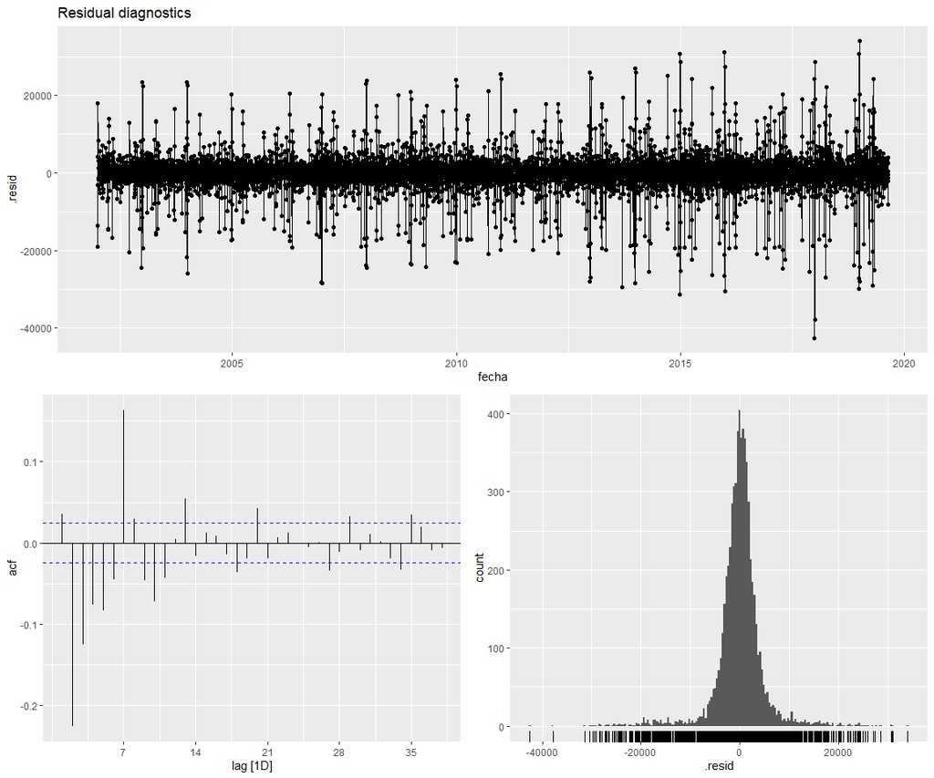

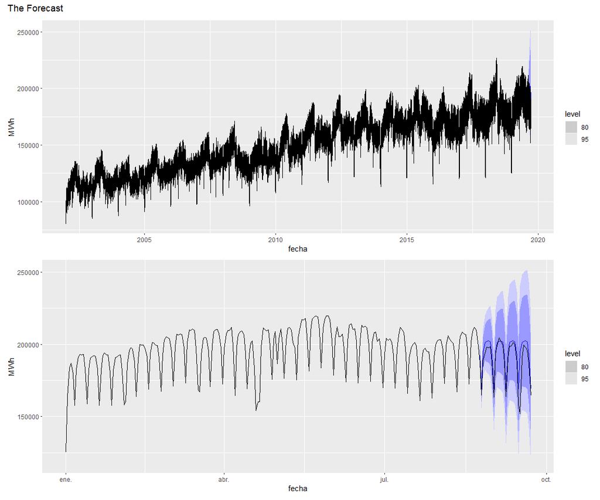

```r
fable_workflow(model = ETS(MWh, opt_crit = "mse"),
               horizon = 30,
               year = 2018)
```

### 4.2.3 `modeltime`

## 4.3 ARIMA

### 4.3.1 .

### 4.3.2 `fable`

```
[1] "The fitted model:"
Series: MWh
Model: ARIMA(1,0,2)(2,1,0)[7]

Coefficients:
         ar1     ma1      ma2     sar1     sar2
      0.7351  0.1529  -0.0757  -0.4803  -0.2884
s.e.  0.0158  0.0208   0.0177   0.0122   0.0120

sigma^2 estimated as 26308527:  log likelihood=-64152.01
AIC=128316   AICc=128316   BIC=128356.6
[1] "Training accuracy:"
```

| .model | .type | ME | RMSE | MAE | MPE | MAPE | MASE | ACF1 |
| --- | --- | --- | --- | --- | --- | --- | --- | --- |
| model | Training | 47.27296 | 5124.408 | 3212.062 | -0.04992785 | 2.166235 | 0.5901846 | 0.0002960949 |

```
[1] "Portmanteau tests for autocorrelation"
```

| .model | lb_stat | lb_pvalue |
| --- | --- | --- |
| model | 35.11147 | 0.000119512 |

```
[1] "The forecast:"
```

| .model | fecha | MWh | .mean |
| --- | --- | --- | --- |
| model | 2019-08-24 |  | 192572.6 |
| model | 2019-08-25 |  | 169684.8 |
| model | 2019-08-26 |  | 198226.7 |
| model | 2019-08-27 |  | 206299.8 |
| model | 2019-08-28 |  | 207983.6 |
| model | 2019-08-29 |  | 206649.1 |
| model | 2019-08-30 |  | 201856.1 |
| model | 2019-08-31 |  | 192865.0 |
| model | 2019-09-01 |  | 169247.5 |
| model | 2019-09-02 |  | 197639.7 |

[output cut: 20 more lines]

```
[1] "Forecast accuracy:"
```

| .model | .type | ME | RMSE | MAE | MPE | MAPE | MASE | ACF1 |
| --- | --- | --- | --- | --- | --- | --- | --- | --- |
| model | Test | -8557.517 | 11492.73 | 8557.517 | -4.73431 | 4.73431 | NaN | 0.3083115 |

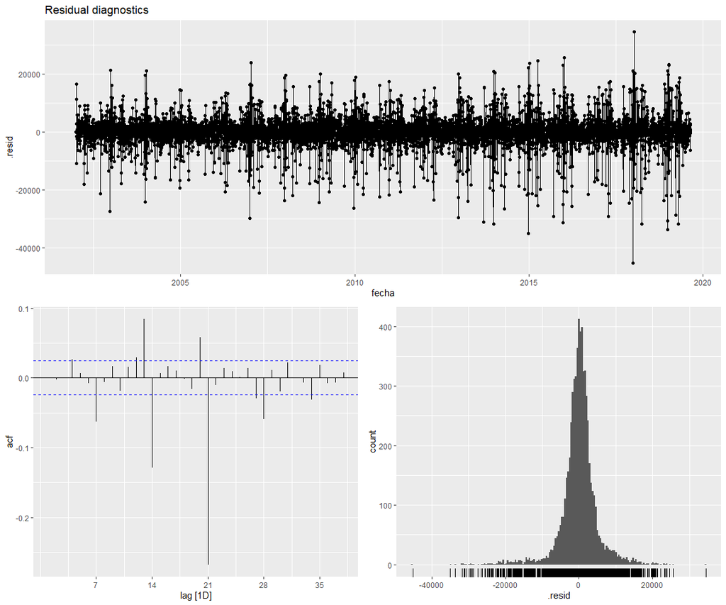

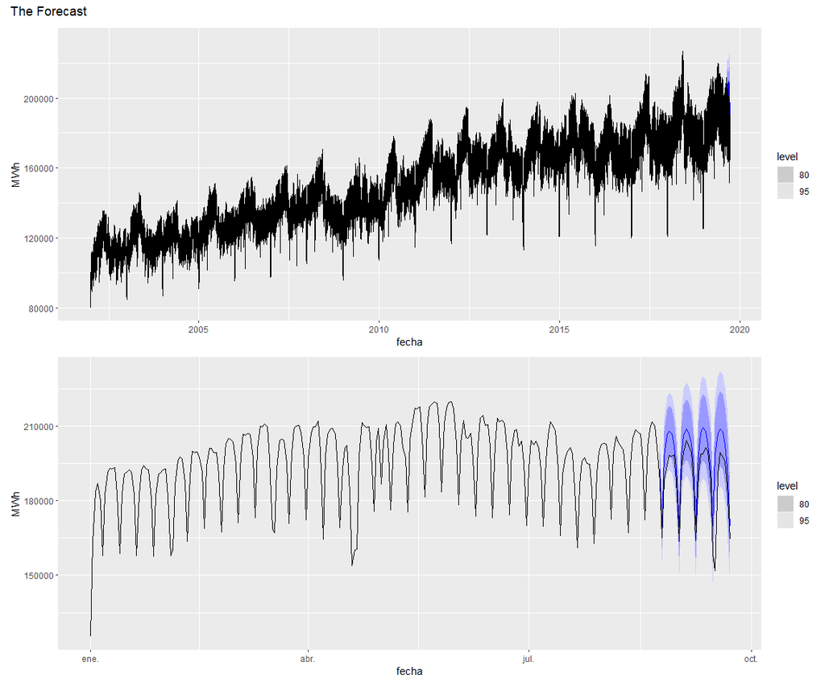

```r
fable_workflow(model = ARIMA(MWh),
               horizon = 30,
               year = 2018)
```

### 4.3.3 `modeltime`

## 4.4 Linear regression

### 4.4.1 .

### 4.4.2 `fable`

```
[1] "The fitted model:"
Series: MWh
Model: TSLM

Residuals:
   Min     1Q Median     3Q    Max
-70875  -5795   -198   6542  32277

Coefficients:
                Estimate Std. Error t value Pr(>|t|)
(Intercept)    1.209e+05  4.050e+02 298.433   <2e-16
trend()        1.228e+01  6.880e-02 178.438   <2e-16
season()week2 -9.643e+02  4.791e+02  -2.013   0.0442
season()week3 -7.284e+03  4.791e+02 -15.204   <2e-16
season()week4 -2.364e+04  4.791e+02 -49.343   <2e-16
season()week5 -7.054e+03  4.791e+02 -14.724   <2e-16
season()week6 -9.198e+02  4.791e+02  -1.920   0.0549
season()week7  1.202e+01  4.791e+02   0.025   0.9800

(Intercept)   ***
trend()       ***
season()week2 *
season()week3 ***
season()week4 ***
season()week5 ***
season()week6 .
season()week7
---
Signif. codes:
0 ‘***’ 0.001 ‘**’ 0.01 ‘*’ 0.05 ‘.’ 0.1 ‘ ’ 1

Residual standard error: 10280 on 6439 degrees of freedom
Multiple R-squared: 0.847,  Adjusted R-squared: 0.8469
F-statistic:  5094 on 7 and 6439 DF, p-value: < 2.22e-16
[1] "Training accuracy:"
```

| .model | .type | ME | RMSE | MAE | MPE | MAPE | MASE | ACF1 |
| --- | --- | --- | --- | --- | --- | --- | --- | --- |
| model | Training | 5.595631e-13 | 10274.32 | 7679.805 | -0.4553104 | 5.081636 | 1.411088 | 0.8703966 |

```
[1] "Portmanteau tests for autocorrelation"
```

| .model | lb_stat | lb_pvalue |
| --- | --- | --- |
| model | 27376.02 | 0 |

```
[1] "The forecast:"
```

| .model | fecha | MWh | .mean |
| --- | --- | --- | --- |
| model | 2019-08-24 |  | 192735.6 |
| model | 2019-08-25 |  | 176392.6 |
| model | 2019-08-26 |  | 192990.1 |
| model | 2019-08-27 |  | 199136.5 |
| model | 2019-08-28 |  | 200080.6 |
| model | 2019-08-29 |  | 200080.9 |
| model | 2019-08-30 |  | 199128.8 |
| model | 2019-08-31 |  | 192821.6 |
| model | 2019-09-01 |  | 176478.6 |
| model | 2019-09-02 |  | 193076.0 |

[output cut: 20 more lines]

```
[1] "Forecast accuracy:"
```

| .model | .type | ME | RMSE | MAE | MPE | MAPE | MASE | ACF1 |
| --- | --- | --- | --- | --- | --- | --- | --- | --- |
| model | Test | -5448.598 | 9993.855 | 5982.729 | -3.253637 | 3.517188 | NaN | 0.3984522 |

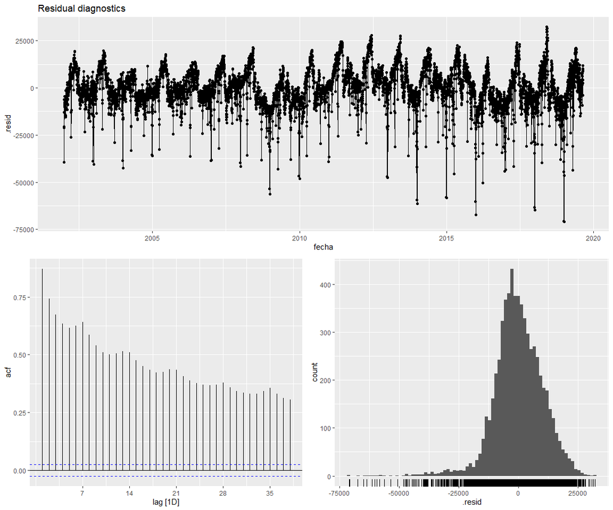

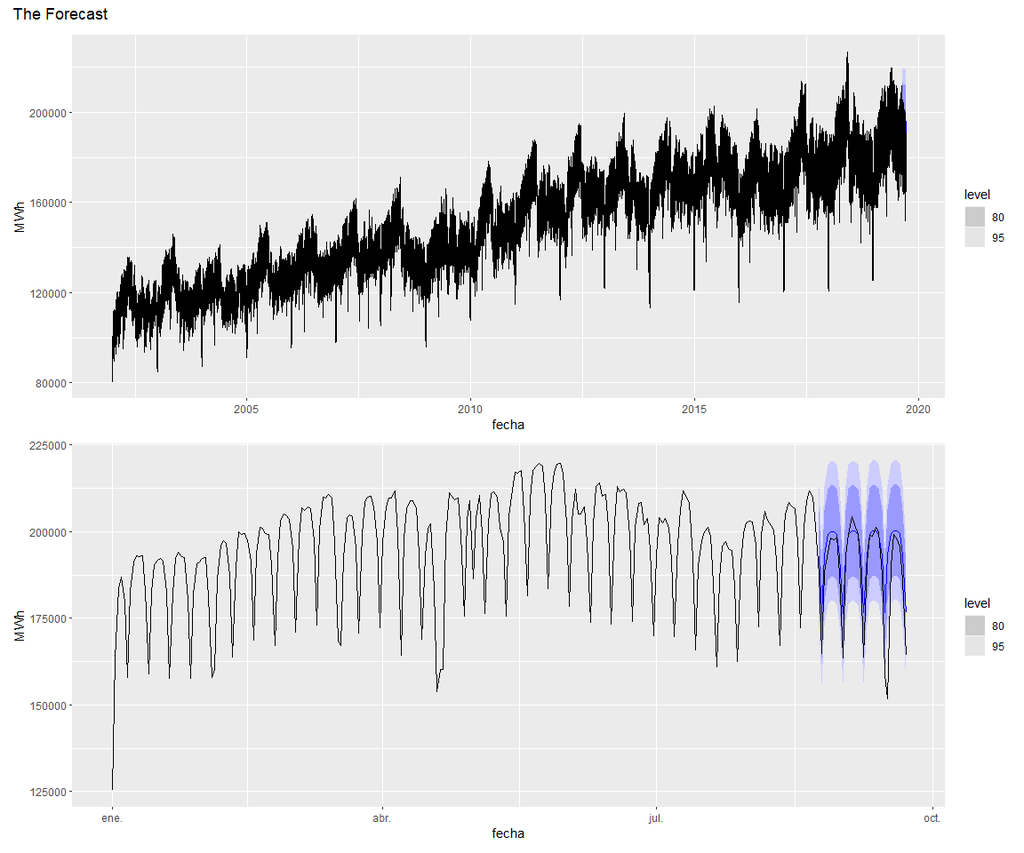

```r
fable_workflow(model = TSLM(MWh ~ trend() + season()),
               horizon = 30,
               year = 2018)
```

### 4.4.3 `modeltime`

## 4.5 Dynamic regression

### 4.5.1 .

### 4.5.2 `fable`

```
[1] "The fitted model:"
Series: MWh
Model: LM w/ ARIMA(2,0,4) errors

Coefficients:
         ar1     ar2     ma1      ma2      ma3
      0.1854  0.7649  0.7259  -0.3654  -0.4059
s.e.  0.0250  0.0239  0.0271   0.0165   0.0200
          ma4  trend()  season()week2  season()week3
      -0.1923  12.2789      -966.8743     -7271.1371
s.e.   0.0128   0.4931       174.9094       240.0885
      season()week4  season()week5  season()week6
        -23630.2506     -7047.1312      -915.5542
s.e.       266.6915       266.6923       240.0921
      season()week7   intercept
            15.3954  120848.325
s.e.       174.9282    1847.866

sigma^2 estimated as 23596563:  log likelihood=-63865.91
AIC=127761.8   AICc=127761.9   BIC=127863.4
[1] "Training accuracy:"
```

| .model | .type | ME | RMSE | MAE | MPE | MAPE | MASE | ACF1 |
| --- | --- | --- | --- | --- | --- | --- | --- | --- |
| model | Training | 4.928502 | 4852.352 | 3037.05 | -0.0964382 | 2.069748 | 0.5580278 | -0.006147252 |

```
[1] "Portmanteau tests for autocorrelation"
```

| .model | lb_stat | lb_pvalue |
| --- | --- | --- |
| model | 353.9072 | 0 |

```
[1] "The forecast:"
```

| .model | fecha | MWh | .mean |
| --- | --- | --- | --- |
| model | 2019-08-24 |  | 195234.5 |
| model | 2019-08-25 |  | 179540.3 |
| model | 2019-08-26 |  | 197388.4 |
| model | 2019-08-27 |  | 203324.7 |
| model | 2019-08-28 |  | 204218.9 |
| model | 2019-08-29 |  | 204048.0 |
| model | 2019-08-30 |  | 203024.7 |
| model | 2019-08-31 |  | 196591.6 |
| model | 2019-09-01 |  | 180166.2 |
| model | 2019-09-02 |  | 196639.0 |

[output cut: 20 more lines]

```
[1] "Forecast accuracy:"
```

| .model | .type | ME | RMSE | MAE | MPE | MAPE | MASE | ACF1 |
| --- | --- | --- | --- | --- | --- | --- | --- | --- |
| model | Test | -8485.209 | 11817.95 | 8538.136 | -4.869506 | 4.895409 | NaN | 0.3806532 |

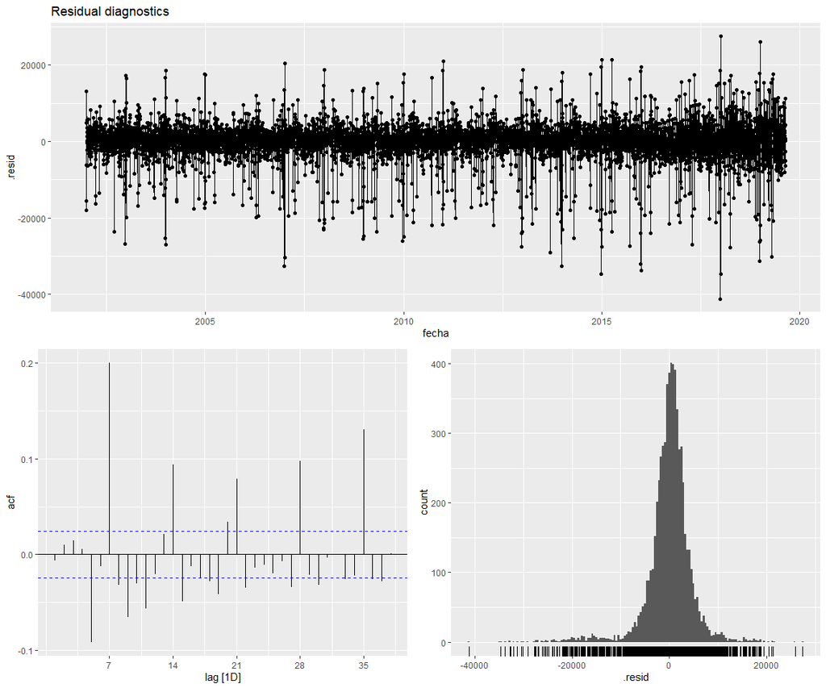

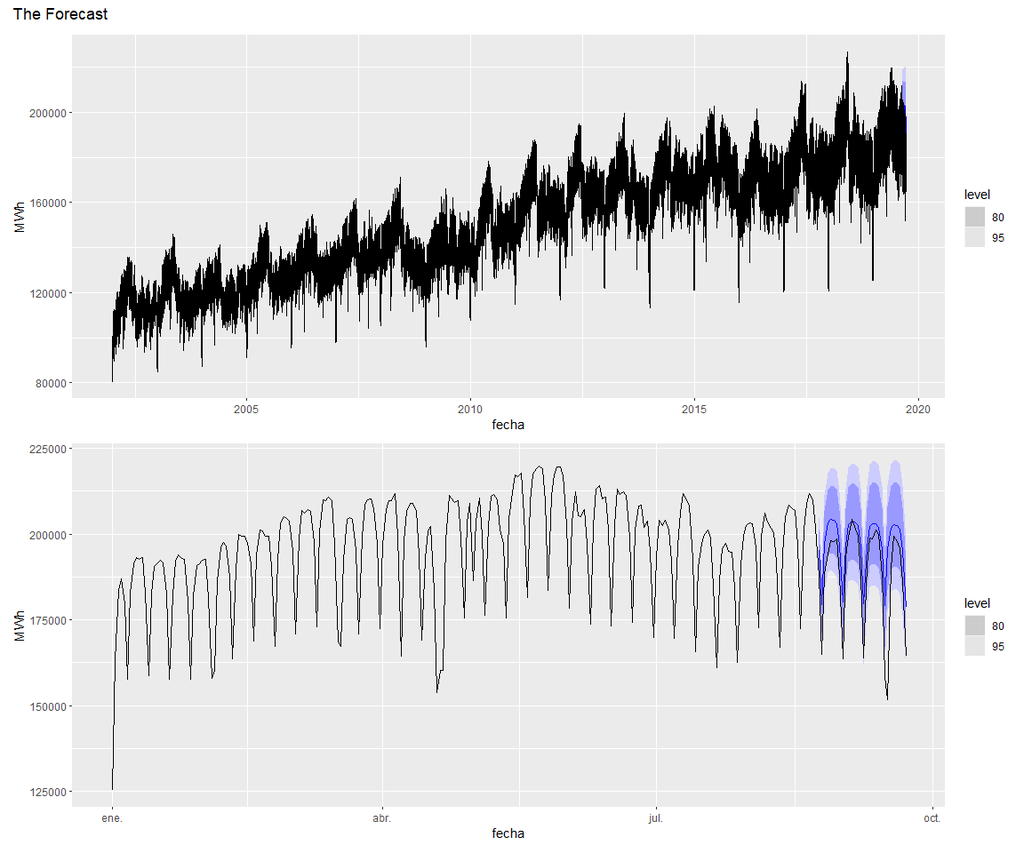

```r
fable_workflow(model = ARIMA(MWh ~ trend() +
                               season() +
                               PDQ(0,0,0)),
               horizon = 30,
               year = 2018)
```

### 4.5.3 `modeltime`

## 4.6 Harmonic dynamic regression

### 4.6.1 .

### 4.6.2 `fable`

```
[1] "The fitted model:"
Series: MWh
Model: LM w/ ARIMA(2,1,3) errors

Coefficients:
          ar1      ar2     ma1      ma2      ma3
      -0.7800  -0.2986  0.2221  -0.1464  -0.6248
s.e.   0.0373   0.0271  0.0337   0.0160   0.0125
      fourier(period = "1 week", K = 2)C1_7
                                  8238.9780
s.e.                               122.5024
      fourier(period = "1 week", K = 2)S1_7
                                 -4042.9256
s.e.                               122.4816
      fourier(period = "1 week", K = 2)C2_7
                                 -3297.7808
s.e.                                80.2622
      fourier(period = "1 week", K = 2)S2_7
                                  4216.8980
s.e.                                80.2686
      fourier(period = "1 year", K = 20)C1_365
                                     -5270.012
s.e.                                  1297.504
      fourier(period = "1 year", K = 20)S1_365
                                      4815.863
s.e.                                  1292.524
      fourier(period = "1 year", K = 20)C2_365
                                    -2218.8986
s.e.                                  656.6836
      fourier(period = "1 year", K = 20)S2_365
                                    -2685.1009
s.e.                                  656.9341
      fourier(period = "1 year", K = 20)C3_365
                                       60.6589
s.e.                                  447.4910
      fourier(period = "1 year", K = 20)S3_365
                                     1386.2111
s.e.                                  448.2985
      fourier(period = "1 year", K = 20)C4_365
                                    -2852.2533
```

[output cut: 89 more lines]

```
                                      -220.3904
s.e.                                   142.7337
      fourier(period = "1 year", K = 20)S19_365
                                       819.8404
s.e.                                   142.7079
      fourier(period = "1 year", K = 20)C20_365
                                      -352.7705
s.e.                                   141.0714
      fourier(period = "1 year", K = 20)S20_365
                                       601.1067
s.e.                                   141.0298

sigma^2 estimated as 33868486:  log likelihood=-65002.99
AIC=130106   AICc=130106.8   BIC=130444.5
[1] "Training accuracy:"
```

| .model | .type | ME | RMSE | MAE | MPE | MAPE | MASE | ACF1 |
| --- | --- | --- | --- | --- | --- | --- | --- | --- |
| model | Training | 55.47403 | 5797.053 | 4108.277 | -0.09503243 | 2.756882 | 0.7548551 | 0.04889327 |

```
[1] "Portmanteau tests for autocorrelation"
```

| .model | lb_stat | lb_pvalue |
| --- | --- | --- |
| model | 1053.499 | 0 |

```
[1] "The forecast:"
```

| .model | fecha | MWh | .mean |
| --- | --- | --- | --- |
| model | 2019-08-24 |  | 194085.6 |
| model | 2019-08-25 |  | 180539.2 |
| model | 2019-08-26 |  | 197949.4 |
| model | 2019-08-27 |  | 204843.1 |
| model | 2019-08-28 |  | 204299.8 |
| model | 2019-08-29 |  | 204623.7 |
| model | 2019-08-30 |  | 205829.9 |
| model | 2019-08-31 |  | 194648.7 |
| model | 2019-09-01 |  | 184384.7 |
| model | 2019-09-02 |  | 194119.6 |

[output cut: 20 more lines]

```
[1] "Forecast accuracy:"
```

| .model | .type | ME | RMSE | MAE | MPE | MAPE | MASE | ACF1 |
| --- | --- | --- | --- | --- | --- | --- | --- | --- |
| model | Test | -6670.475 | 10769.83 | 7325.563 | -3.9083 | 4.236117 | NaN | 0.276634 |

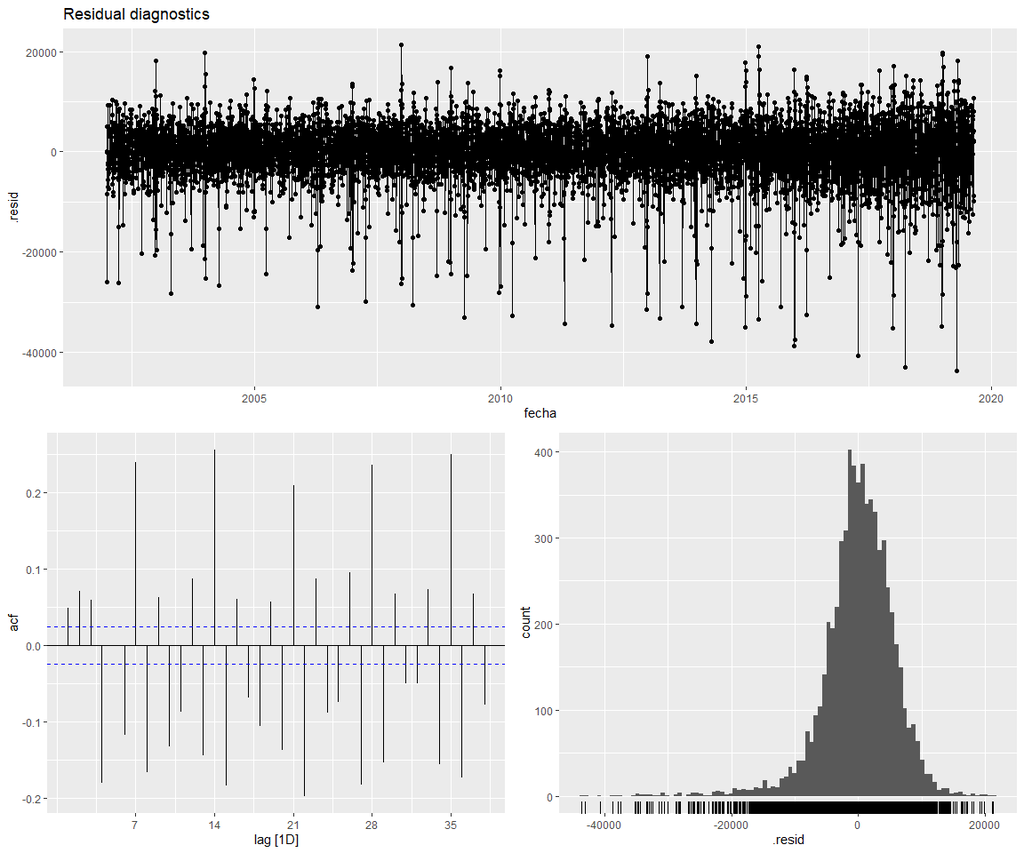

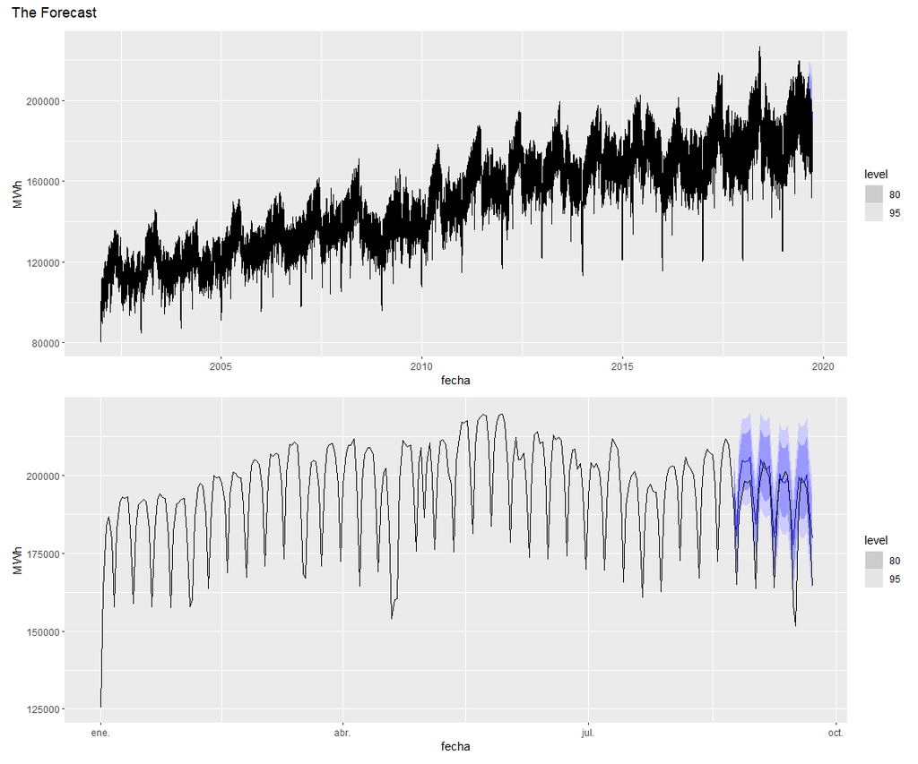

```r
fable_workflow(model = ARIMA(MWh ~ fourier(period = "1 week", K = 2) +
                               fourier(period = "1 year", K = 20) +
                               PDQ(0,0,0)),
               horizon = 30,
               year = 2018)
```

### 4.6.3 `modeltime`

## 4.7 Prophet

### 4.7.1 .

### 4.7.2 `fable`

```
[1] "The fitted model:"
Series: MWh
Model: prophet

A model specific report is not available for this model class.[1] "Training accuracy:"
```

| .model | .type | ME | RMSE | MAE | MPE | MAPE | MASE | ACF1 |
| --- | --- | --- | --- | --- | --- | --- | --- | --- |
| model | Training | 0.1983139 | 7095.128 | 4987 | -0.214222 | 3.381001 | 0.9163119 | 0.7297187 |

```
[1] "Portmanteau tests for autocorrelation"
```

| .model | lb_stat | lb_pvalue |
| --- | --- | --- |
| model | 7765.018 | 0 |

```
[1] "The forecast:"
```

| .model | fecha | MWh | .mean |
| --- | --- | --- | --- |
| model | 2019-08-24 |  | 193711.8 |
| model | 2019-08-25 |  | 177047.3 |
| model | 2019-08-26 |  | 193270.9 |
| model | 2019-08-27 |  | 198765.5 |
| model | 2019-08-28 |  | 200276.2 |
| model | 2019-08-29 |  | 199073.3 |
| model | 2019-08-30 |  | 197766.8 |
| model | 2019-08-31 |  | 190764.0 |
| model | 2019-09-01 |  | 174135.0 |
| model | 2019-09-02 |  | 190758.9 |

[output cut: 20 more lines]

```
[1] "Forecast accuracy:"
```

| .model | .type | ME | RMSE | MAE | MPE | MAPE | MASE | ACF1 |
| --- | --- | --- | --- | --- | --- | --- | --- | --- |
| model | Test | -1730.374 | 8554.227 | 5786.218 | -1.261278 | 3.297246 | NaN | 0.393794 |

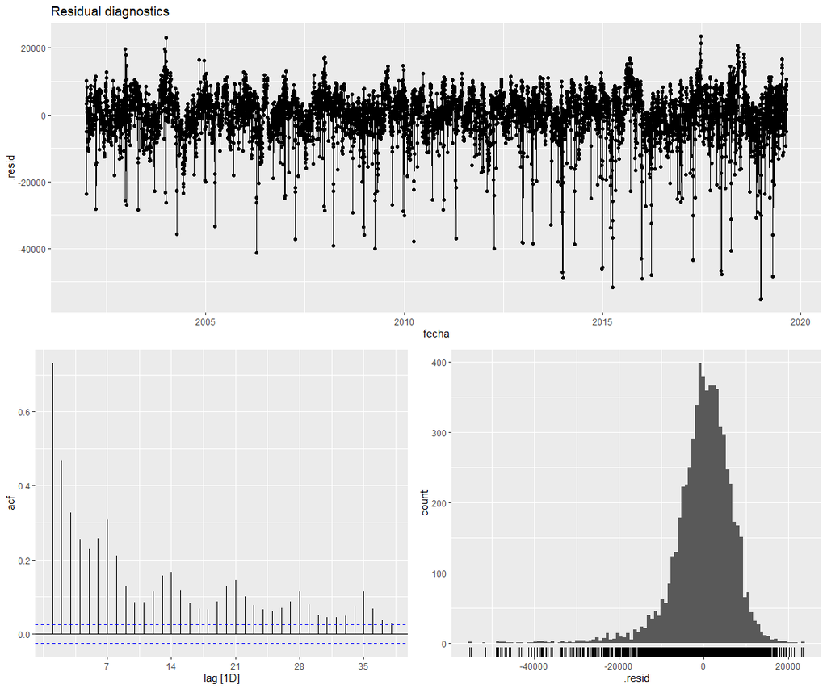

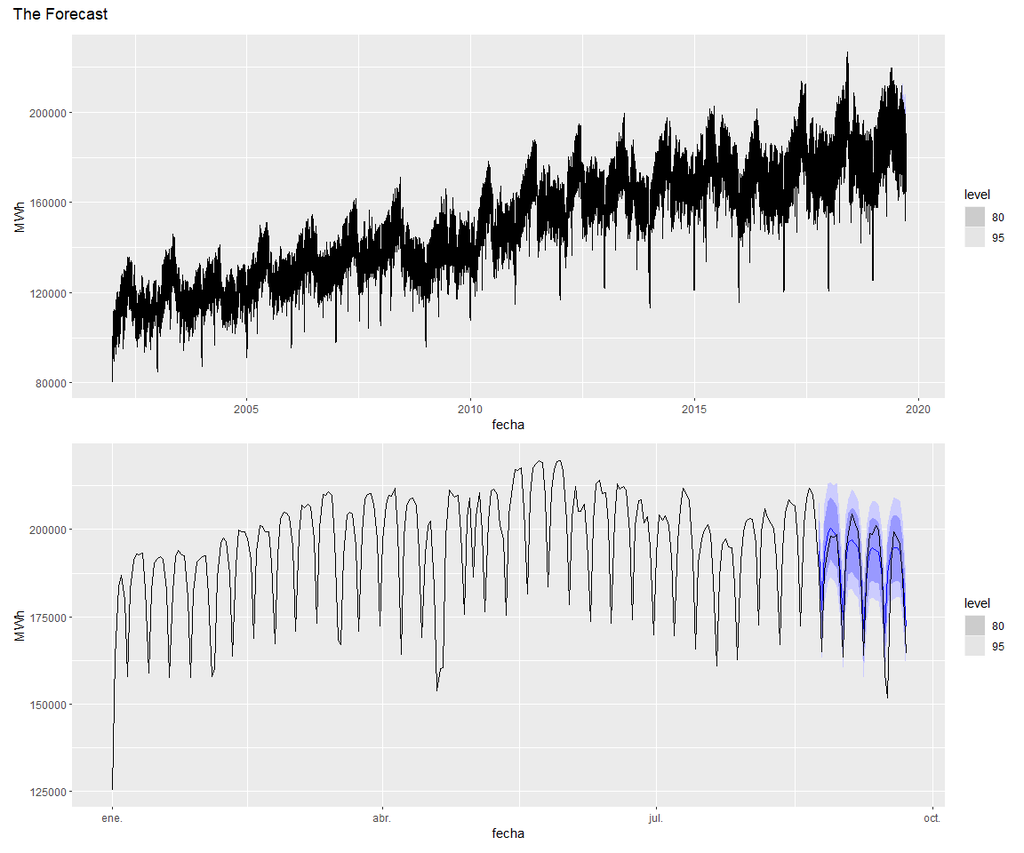

```r
fable_workflow(model = prophet(MWh),
               horizon = 30,
               year = 2018)
```